# HW3

Nihaal Rahman (nkr2121)

## Problem 1

Loading in the dataset.

```r
library(p8105.datasets)
data("instacart")
```

This dataset contains 1384617 rows and 15 columns, with each row representing a single product from an instacart order. There are ID variables indicating the user, order, and product. Other variables of interest include order_hour_of_day and days_since_prior_order, which could be useful for seeing trends among instacart users. In total, there are 39123 products found in 131209 orders from 131209 distinct users.

How many aisles are there?

```r
instacart |> distinct(aisle) |> count()
```

```
## # A tibble: 1 × 1
##       n
##   <int>
## 1   134
```

There are 134 aisles in this dataset.

Which aisles are the most items ordered from?

```r
instacart |>
  count(aisle) |>
  arrange(desc(n))
```

```
## # A tibble: 134 × 2
##    aisle                              n
##    <chr>                          <int>
##  1 fresh vegetables              150609
##  2 fresh fruits                  150473
##  3 packaged vegetables fruits     78493
##  4 yogurt                         55240
##  5 packaged cheese                41699
##  6 water seltzer sparkling water  36617
##  7 milk                           32644
##  8 chips pretzels                 31269
##  9 soy lactosefree                26240
## 10 bread                          23635
## # ℹ 124 more rows
```

Now making a plot that shows the number of items ordered in each aisle, limiting this to aisles with more than 10000 items ordered.

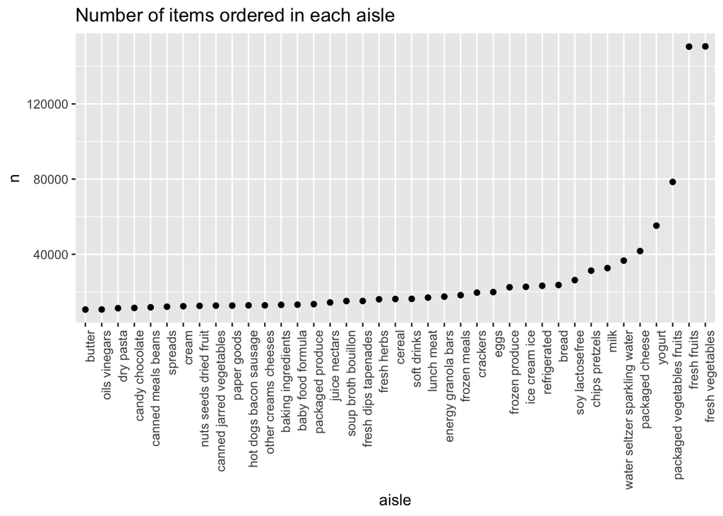

```r
instacart |>
  count(aisle) |>
  filter(n > 10000) |>
  mutate(aisle = fct_reorder(aisle, n)) |>
  ggplot(aes(x = aisle, y = n)) +
  geom_point() +
  labs(title = "Number of items ordered in each aisle") +
  theme(axis.text.x = element_text(angle = 90, hjust = 1))
```

As you can see through the plot, top 5 aisles for most items ordered from are, in order: fresh vegetables, fresh fruits, packaged vegetables fruits, yogurt, and packaged cheese.

Now making a table showing the three most popular items in each of the aisles “baking ingredients”, “dog food care”, and “packaged vegetables fruits”. Include the number of times each item is ordered in your table.

```r
instacart |>
  filter(aisle %in% c("baking ingredients", "dog food care", "packaged vegetables fruits")) |>
  group_by(aisle) |>
  count(product_name) |>
  mutate(rank = min_rank(desc(n))) |>
  filter(rank < 4) |>
  arrange(desc(n)) |>
  knitr::kable()
```

| aisle | product_name | n | rank |
| --- | --- | --- | --- |
| packaged vegetables fruits | Organic Baby Spinach | 9784 | 1 |
| packaged vegetables fruits | Organic Raspberries | 5546 | 2 |
| packaged vegetables fruits | Organic Blueberries | 4966 | 3 |
| baking ingredients | Light Brown Sugar | 499 | 1 |
| baking ingredients | Pure Baking Soda | 387 | 2 |
| baking ingredients | Cane Sugar | 336 | 3 |
| dog food care | Snack Sticks Chicken & Rice Recipe Dog Treats | 30 | 1 |
| dog food care | Organix Chicken & Brown Rice Recipe | 28 | 2 |
| dog food care | Small Dog Biscuits | 26 | 3 |

The most popular items from packaged vegetables fruits are: (1) organic baby spinach, (2) organic raspberries, and (3) organic blueberries.

The most popular items from baking ingredients are: (1) light brown sugar, (2) pure baking soda, and (3) cane sugar.

The most popular items from dog food care are: (1) snack sticks chicken & rice recipe dog treats, (2) organix chicken & brown rice recipe, and (3) small dog biscuits.

Now making a table showing the mean hour of the day at which Pink Lady Apples and Coffee Ice Cream are ordered on each day of the week. format this table for human readers (i.e. produce a 2 x 7 table).

```r
instacart |>
  filter(product_name %in% c("Pink Lady Apples", "Coffee Ice Cream")) |>
  group_by(product_name, order_dow) |>
  summarize(mean_hour = mean(order_hour_of_day)) |>
  pivot_wider(
    names_from = order_dow,
    values_from = mean_hour) |>
  knitr::kable(digits = 2)
```

| product_name | 0 | 1 | 2 | 3 | 4 | 5 | 6 |
| --- | --- | --- | --- | --- | --- | --- | --- |
| Coffee Ice Cream | 13.77 | 14.32 | 15.38 | 15.32 | 15.22 | 12.26 | 13.83 |
| Pink Lady Apples | 13.44 | 11.36 | 11.70 | 14.25 | 11.55 | 12.78 | 11.94 |

## Problem 2

Importing the data

```r
data("brfss_smart2010")
```

Data cleaning

```r
brfss_smart2010 = brfss_smart2010 |>
  janitor::clean_names() |>
  filter(topic == "Overall Health") |>
  mutate(response = factor(response, levels = c("Poor", "Fair", "Good", "Very good",
                                                "Excellent"), ordered = TRUE))
```

In 2002, which states were observed at 7 or more locations? What about in 2010?

```r
brfss_smart2010 |>
  filter(year %in% c(2002, 2010)) |>
  group_by(year, locationabbr) |>
  summarize(locationdesc = n_distinct(locationdesc)) |>
  filter(locationdesc >= 7)
```

```
## # A tibble: 20 × 3
## # Groups:   year [2]
##     year locationabbr locationdesc
##    <int> <chr>               <int>
##  1  2002 CT                      7
##  2  2002 FL                      7
##  3  2002 MA                      8
##  4  2002 NC                      7
##  5  2002 NJ                      8
##  6  2002 PA                     10
##  7  2010 CA                     12
##  8  2010 CO                      7
##  9  2010 FL                     41
## 10  2010 MA                      9
## 11  2010 MD                     12
## 12  2010 NC                     12
## 13  2010 NE                     10
## 14  2010 NJ                     19
## 15  2010 NY                      9
## 16  2010 OH                      8
## 17  2010 PA                      7
## 18  2010 SC                      7
## 19  2010 TX                     16
## 20  2010 WA                     10
```

In 2002, the following 6 states were observed at 7 or more locations: CT, FL, MA, NC, NJ, and PA. In 2010, the following 14 states were observed at 7 or more locations: CA, CO, FL, MA, MD, NC, NE, NJ, NY, OH, PA, SC, TX, and WA. CT is the only state that was observed at 7 or more locations in 2002, but not in 2010.

Now constructing a dataset that is limited to Excellent responses, and contains, year, state, and a variable that averages the data_value across locations within a state.

```r
data = brfss_smart2010 |>
  filter(response == "Excellent") |>
  group_by(locationabbr, year) %>%
  summarize(avg_data_value = mean(data_value, na.rm = TRUE)) |>
  select(year, locationabbr, avg_data_value)
```

Making a “spaghetti” plot of this average value over time within a state.

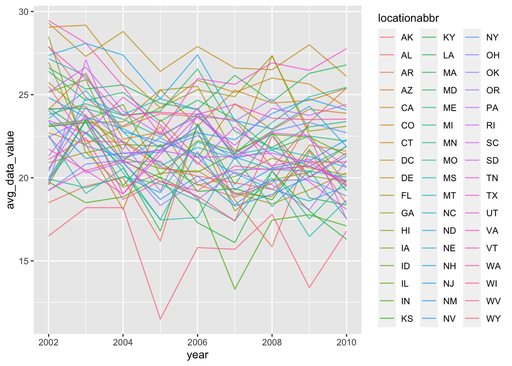

```r
ggplot(data = data, aes(x = year, y = avg_data_value, group = locationabbr, color = locationabbr)) +
  geom_line(alpha = 0.7)
```

This plot shows the average value over time within each state. The average data value in 2002 across all states was 23.37. In 2003 the average data value was 23.41. In 2004 the average data value was 22.02. In 2005 the average data value was 21.37. In 2006 the average data value was 22.04. In 2007 the average data value was 21.14. In 2008 the average data value was 21.64. In 2009 the average data value was 21.53. In 2010 the average data value was 21.23.

Making a two-panel plot showing, for the years 2006, and 2010, distribution of data_value for responses (“Poor” to “Excellent”) among locations in NY State.

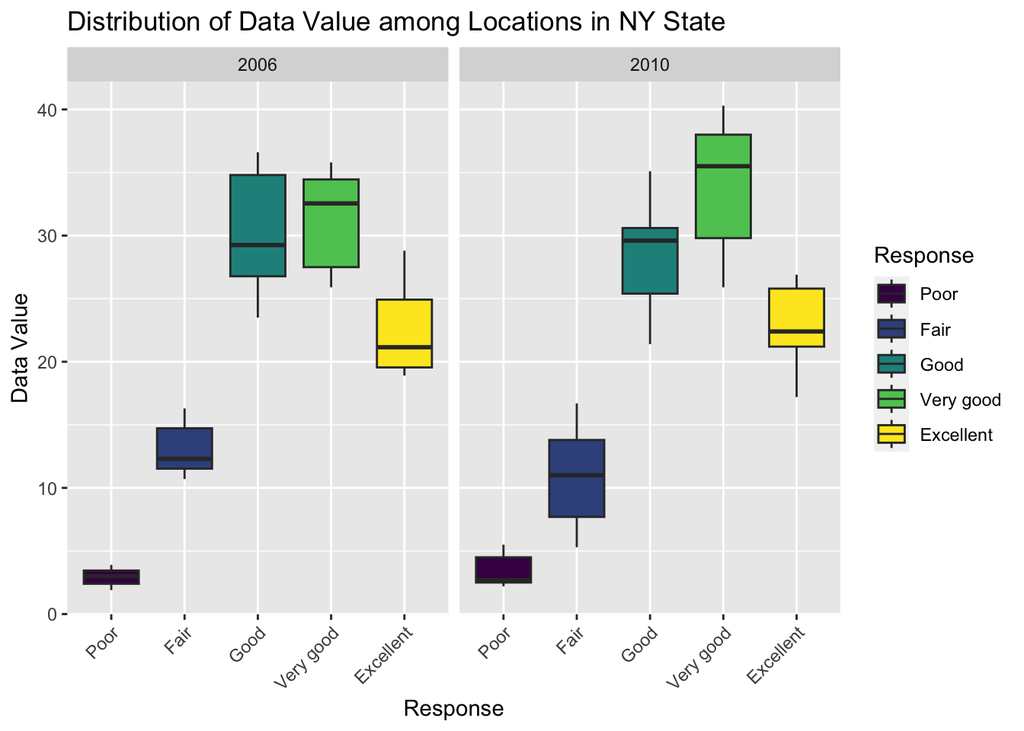

```r
brfss_smart2010 |>
  filter(locationabbr == "NY" & (year == 2010 | year == 2006)) |>
  ggplot(aes(x = response, y = data_value, fill = response)) +
  geom_boxplot() +
  facet_grid(~year) +
  theme(axis.text.x = element_text(angle = 45, hjust = 1)) +
  labs(
    title = "Distribution of Data Value among Locations in NY State",
    x = "Response",
    y = "Data Value",
    fill = "Response"
  )
```

## Problem 3

Loading, tidying, merging, and otherwise organizing the data sets.

```r
covar <- read_csv("~/Downloads/nhanes_covar.csv", skip = 4)
accel <- read_csv("~/Downloads/nhanes_accel.csv")
merged_data = left_join(covar, accel, by = "SEQN") |>
  janitor::clean_names() |>
  filter(!is.na(sex) & !is.na(age) & !is.na(bmi) & !is.na(education)) |>
  filter(age >= 21) |>
  mutate(sex = ifelse(sex == 1, "male", "female")) |>
  mutate(education = ifelse(education == 1, "Less than high school",
                            ifelse(education == 2, "High school equivalent", "More than high school"))) |>
  mutate(education = factor(education, levels = c("Less than high school", "High school equivalent", "More than high school")))
```

Producing a reader-friendly table for the number of men and women in each education category

```r
merged_data |>
  janitor::tabyl(sex, education)
```

```
##     sex Less than high school High school equivalent More than high school
##  female                    28                     23                    59
##    male                    27                     35                    56
```

Overall, there are more men in this data set than women. Within men and women each, respectively, about half have more than a high school education, and the remaining half is split between less than high school and high school equivalent educations.

Creating a visualization of the age distributions for men and women in each education category.

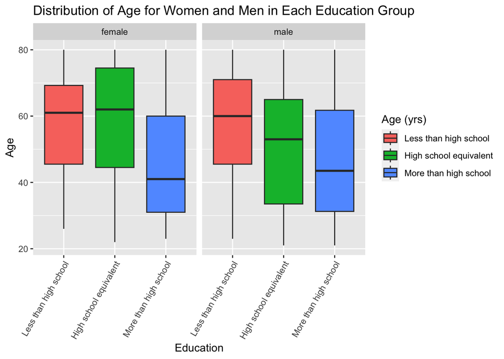

```r
merged_data |>
  ggplot(aes(x = education, y = age, fill = education)) +
  geom_boxplot() +
  facet_grid(~sex) +
  theme(axis.text.x = element_text(angle = 60, hjust = 1)) +
  labs(
    title = "Distribution of Age for Women and Men in Each Education Group",
    x = "Education",
    y = "Age",
    fill = "Age (yrs)"
  )
```

In both men and women, the more than high school group has an younger average age than the other two groups. In women, the average age for the less than high school and high school equivalent group are about the same, but in men, there is a gradient of average ages, getting younger as the educational attainment level increases.

Using the tidied dataset, aggregating across minutes to create a total activity variable for each participant. Plotting these total activities (y-axis) against age (x-axis), while comparing men to women with separate panels for each education level, and including a smooth to illustrate differences.

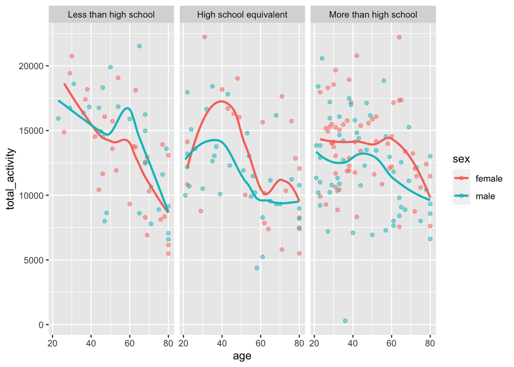

```r
merged_data %>%
  mutate(total_activity = rowSums(select(., starts_with("min")), na.rm = TRUE)) |>
  ggplot(aes(x = age, y = total_activity, color = sex)) +
  facet_grid(~education) +
  geom_point(alpha = .5) +
  geom_smooth(se = FALSE)
```

Making a three-panel plot that shows the 24-hour activity time courses for each education level and use color to indicate sex.

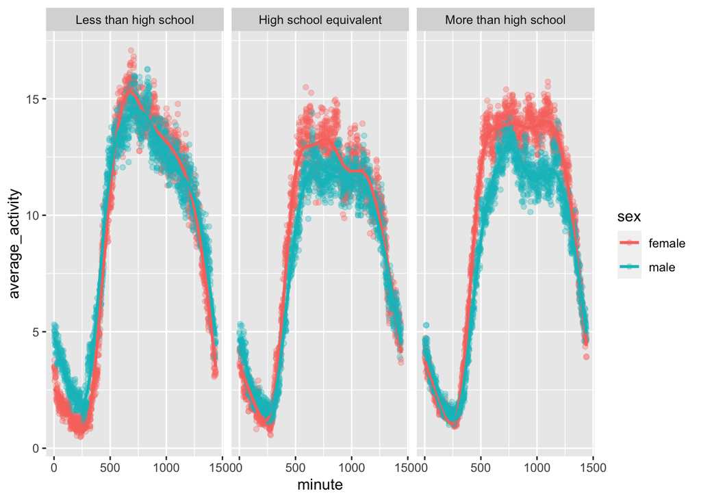

```r
merged_data |>
  pivot_longer(cols = starts_with("min"), names_to = "minute", values_to = "activity") |>   mutate(minute = str_remove(minute, "min")) |>
  mutate(minute = as.numeric(minute)) |>
  group_by(sex, minute, education) |>
  summarize(average_activity = mean(activity, na.rm = TRUE)) |>
  ggplot(aes(x = minute, y = average_activity, color = sex)) +
  facet_grid(~education) +
  geom_point(alpha = .3) +
  geom_smooth(se = FALSE)
```